# Linear Regression

Mon Dec 05, 2016

## Final Note about Confidence Intervals

- **ALL** confidence intervals have form: \(\mbox{Point Estimate}\pm 2 \times SE\)
- What the point estimate and SE are will change
- CI for \(\mu\):
  - Point estimate: \(\overline{x}\)
  - SE = \(\frac{s}{\sqrt{n}}\)
  - 95% CI: \(\overline{x} \pm 2 \frac{s}{\sqrt{n}} = \left(\overline{x} - 2 \frac{s}{\sqrt{n}}, \overline{x} + 2 \frac{s}{\sqrt{n}}\right)\)
- PS-11: CI for \(\mu_1 - \mu_2\) i.e. Difference in means of two groups
  - Point estimate: \(\overline{x}_1 - \overline{x}_2\)
  - SE = NASTY!

## Correlation Coefficient

- Measures the strength of linear association between two variables
- Always between [-1, 1] where
  - -1 indicates perfect negative relationship
  - 0 indicates no relationship
  - +1 indicates perfect positive relationship

## Correlation Coefficient

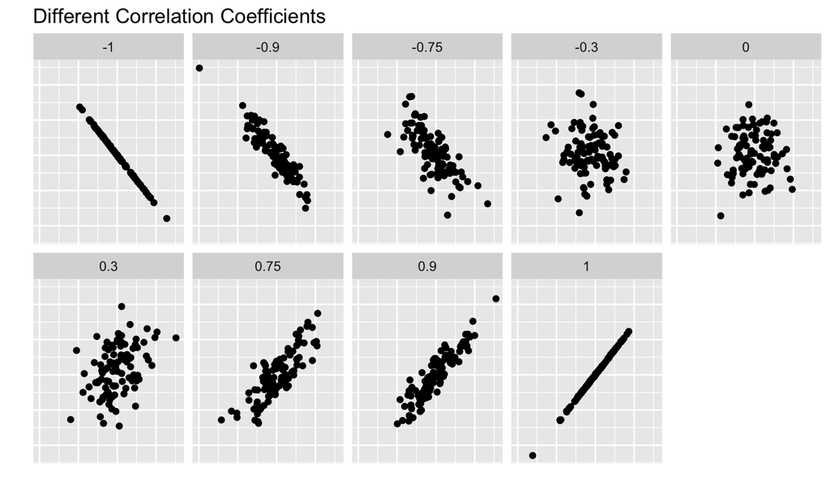

## Correlation Coefficient

Two versions: Just like with \(\mu\) and \(\overline{x}\)

- **Population correlation coefficient** \(\rho\)
- **Sample correlation coefficent** \(r\) based on a sample of n **pairs** of observations

## Example

Recall the `nycflights` data set. For Alaska Air flights, let's explore the **relationship** between

- Departure delay
- Arrival delay

```r
library(nycflights13)
data(flights)

# Load Alaska data, deleting rows that have missing dep or arr data
alaska_flights <- flights %>%
  filter(carrier == "AS") %>%
  filter(!is.na(dep_delay) & !is.na(arr_delay))

ggplot(data=alaska_flights, aes(x = dep_delay, y = arr_delay)) +
   geom_point()
```

## Example

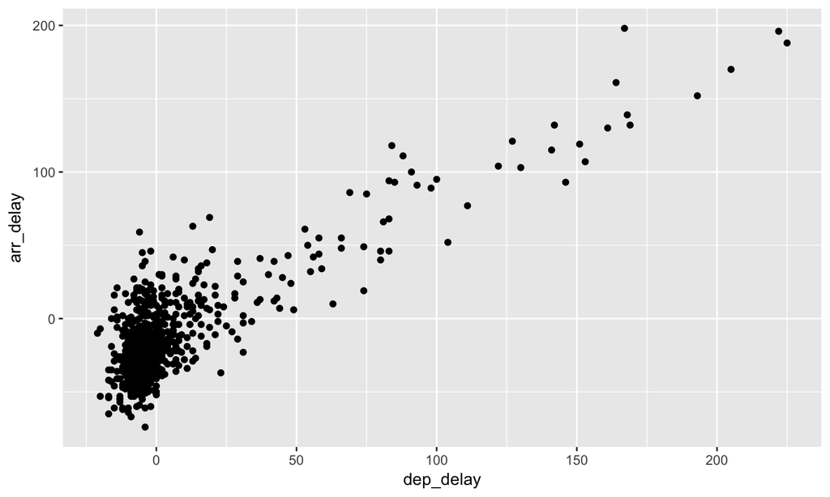

## Example

The correlation coefficient is computed as follows:

```r
cor(alaska_flights$dep_delay, alaska_flights$arr_delay)
```

```
## [1] 0.8373792
```

This is fairly strongly **positively associated**!

## Bored?

Play [Guess the Correlation](http://guessthecorrelation.com/)

## Important Note

**Correlation coefficent \(\neq\) slope of regression line.** Example: Say we have 3 group of points

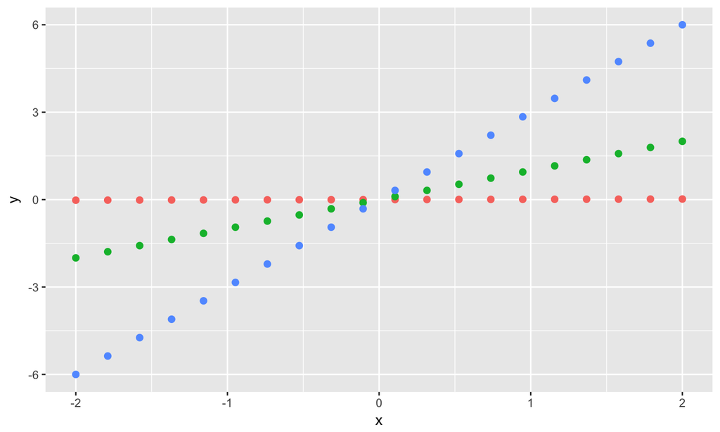

## Important Note

Their regression lines have different slopes, but \(r= 1\) for all 3. i.e. perfect (positive) linear relationship.

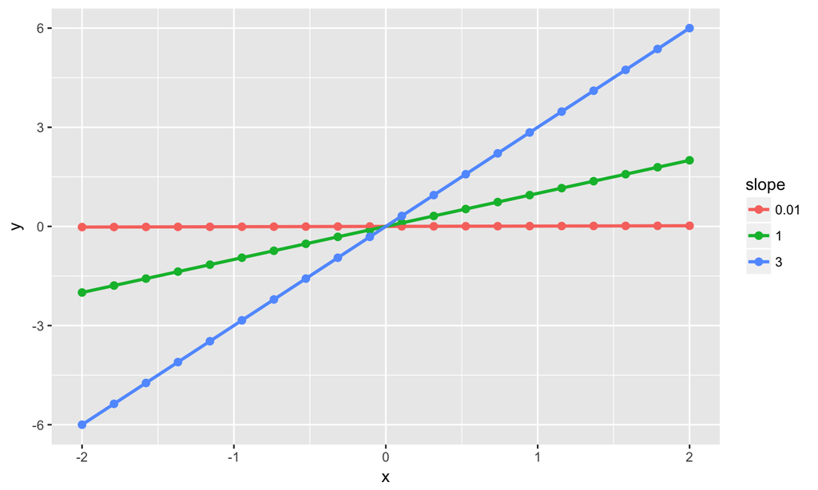